# Practical Machine Learning Course Project

Elvis Ilunga

28 October 2016

# Introduction

## Background

From the website  
Using devices such as Jawbone Up, Nike FuelBand, and Fitbit it is now possible to collect a large amount of data about personal activity relatively inexpensively. These type of devices are part of the quantified self movement - a group of enthusiasts who take measurements about themselves regularly to improve their health, to find patterns in their behavior, or because they are tech geeks. One thing that people regularly do is quantify how much of a particular activity they do, but they rarely quantify how well they do it. In this project, your goal will be to use data from accelerometers on the belt, forearm, arm, and dumbell of 6 participants. They were asked to perform barbell lifts correctly and incorrectly in 5 different ways. More information is available from the website here: http://groupware.les.inf.puc-rio.br/har (see the section on the Weight Lifting Exercise Dataset).

# Objective

The goal of this project is to predict the manner in which they did the exercise. This is the “classe” variable in the training set. We may use any of the other variables to predict with. We should create a report describing how you built your model, how we used cross validation, what we think the expected out of sample error is, and why we made the choices we did. We will also use our prediction model to predict 20 different test cases.

# Data Preprocessing

## Data overview

The training data for this project are available here:

https://d396qusza40orc.cloudfront.net/predmachlearn/pml-training.csv

The test data are available here:

https://d396qusza40orc.cloudfront.net/predmachlearn/pml-testing.csv  
The data for this project come from this source: http://groupware.les.inf.puc-rio.br/har.

## Data description

From the website:  
“Six young health participants were asked to perform one set of 10 repetitions of the Unilateral Dumbbell Biceps Curl in five different fashions: exactly according to the specification (Class A), throwing the elbows to the front (Class B), lifting the dumbbell only halfway (Class C), lowering the dumbbell only halfway (Class D) and throwing the hips to the front (Class E).”

# Environment

```r
library(knitr)
library(caret)
```

```r
library(rpart)
library(rpart.plot)
library(rattle)
library(randomForest)
library(MASS)
library(gbm)
library(ggplot2)
```

# Data Loading and Cleaning

I read in the two provided data sets, I discarded the respected last variable from each so to be able to combine them into one full data set and proceed to clean it once for all. Get rid of columns with more than 50% missing values (NA), and unnecessary variables such as user_name that will not help in the prediction, and finally those variables with near zero variance.

```r
Training <- read.csv("pml-training.csv")
Testing <- read.csv("pml-testing.csv")
new_Training <- Training[,-160]
new_Testing <- Testing[,-160]
full_case <- rbind(new_Training,new_Testing)
is.na(full_case) <- full_case == c("NA","#DIV/0!","")
sum(is.na(full_case))
```

```
## [1] 1502018
```

```r
full_case <- full_case[, -c(1:7)]
```

```r
clean_case <- full_case #creating another subset to iterate in loop
for(i in 1:length(full_case)) { #for every column in the training dataset
  if( sum( is.na(full_case[, i] ) ) /nrow(full_case) >= .5 ) { #if n?? NAs > 50% of total observations
    for(j in 1:length(clean_case)) {
      if( length( grep(names(full_case[i]), names(clean_case)[j]) ) ==1)  { #if the columns are the same:
        clean_case <- clean_case[ , -j] #Remove that column
      }
    }
  }
}
badCol <- nearZeroVar(clean_case, saveMetrics = T) #discarding variables with near zero variance
clean_case <- clean_case[, badCol$nzv==F]
```

```r
##Let get back to the original Training and Testing set (the 20 last obs)
clean_Training <- clean_case[1:19622,]
clean_Testing <- clean_case[19623:19642,]
clean_Testing$problem_id <- Testing$problem_id
clean_Training$classe <- factor(Training$classe) #transfoming the outcome variable
```

# Cross Validation

We performed a cross validation by subsampling our training data set randomly without replacement into 2 subsamples: subtraining data (70% of the original Training data set) and subtesting data (30%) as the original sample size is quite big enough.

```r
intrain <- createDataPartition(y=clean_Training$classe, p=0.7,list = F)
smallTraining <- clean_Training[intrain,]
smallTesting <- clean_Training[-intrain,]
```

# Exploratory Data Analysis

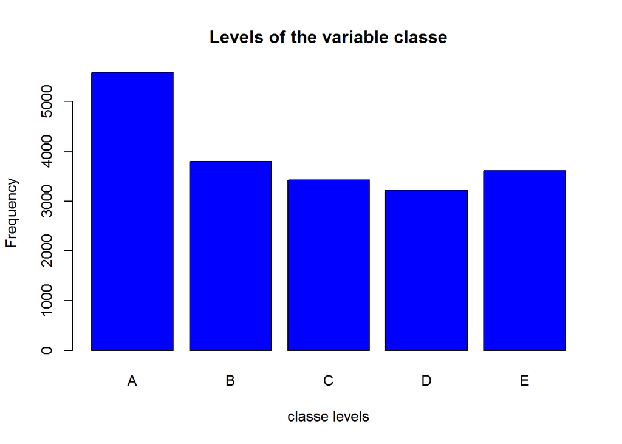

```r
plot(clean_Training$classe, col="blue", main="Levels of the variable classe", xlab="classe levels", ylab="Frequency")
```

The plot above shows that Level A is the most frequent classe. D appears to be the least frequent one.